# Analysis & plots for paper: Seasonal habitat use and diel vertical migration in female spurdog in Nordic waters, Movement Ecology

### 5.3.2 DVM Summary

Figure 3A & B: Individual differences in DVM behaviour across a year. Colours indicate tagging years (2019-blue, 2020-green, 2021-yellow, 2022-red). (A) Overall proportion of DVM behaviour displayed on a given Julian day based on B. (B) Occurrence of significant DVM behaviour for each shark by Julian day. Dark bands denote days identified as showing predominantly significant DVM behaviour (based on significant 24h period in wavelet power), while light bands refer to days at which this is not the case. Coloured vertical lines present the Julian day of tagging. Data gaps due to different deployment durations are shown in white

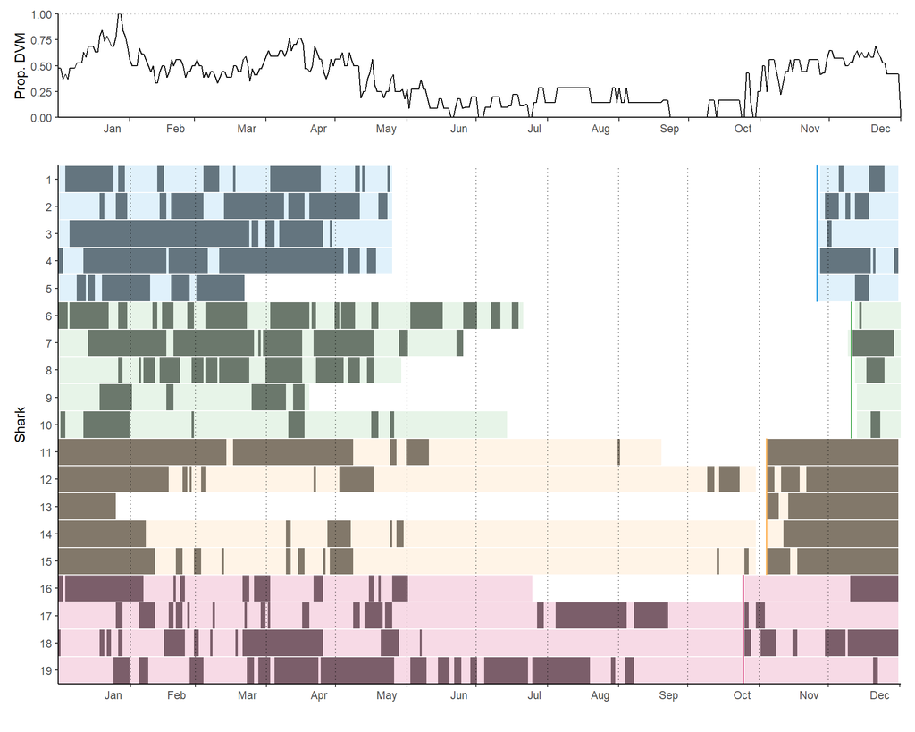

```r
t <- ddata %>% mutate(yday= yday(Date),
                      DVM = as.numeric(DVM == "DVM"),
                      sharkID = fct_rev(sharkID)) %>% dplyr::select(yday, sharkID, DVM, cohort) #%>%  pivot_wider(names_from = yday, values_from = DVM)

# fig 3A
p1 <- ggplot(t, aes(x= yday, y= sharkID))+
  geom_tile(aes(fill = cohort),alpha = 0.5)+
  scale_fill_manual(values = c("#34a2e5ff","#5fb667ff", "#feb55dff","#cd0e5bff"), guide ="none")+
  ggnewscale::new_scale_fill() +
  geom_tile(aes(fill = DVM),alpha = 0.7)+
  scale_fill_gradientn(colors = c("white","grey30"), guide ="none")+
  geom_hline(yintercept = seq(1.5,19.5,1), colour = "white", linetype = "solid")+
  geom_vline(xintercept = c(32,60, 91, 182,121,152,213, 244,274, 305, 335), colour = "black",alpha = 0.5, linetype = "dotted", linewidth = 0.5)+
  geom_segment(x = yday("2022-10-25"), xend = yday("2022-10-25"),y = 0.5, yend=4.5, colour = "#cd0e5bff", linewidth = 0.7, linetype = "solid")+
  geom_segment(x = yday("2021-11-04"), xend = yday("2021-11-04"),y = 4.5, yend=9.5 , colour =  "#feb55dff",linewidth = 0.7, linetype = "solid")+
  geom_segment(x = yday("2020-12-10"), xend = yday("2020-12-10"),y = 9.5, yend=14.5, colour = "#5fb667ff",linewidth = 0.7, linetype = "solid")+
  geom_segment(x = yday("2019-11-26"), xend = yday("2019-11-26"),  y = 14.5, yend=19.5, colour = "#34a2e5ff",linewidth = 0.7, linetype = "solid")+
  scale_x_continuous(expand = c(0,0), breaks = c(32,60,91,121,152,182,213,244,274,305,335,366), labels= c("Jan", "Feb","Mar","Apr","May","Jun", "Jul", "Aug","Sep","Oct","Nov", "Dec"))+
  scale_y_discrete(expand = c(0,0))+
  labs(x= "", y = "Shark", fill = "DVM")+
  theme_classic()+
  theme(axis.text.x = element_text(hjust = 1.5))
ggsave(p1, filename = paste0("plots/spurdog/paper/DVM_tiles_cohort.png"), width = 14, height = 10, units = "cm")

# overall prop of DVM displayed
t_count <- t %>% group_by(yday) %>% summarise(dens = sum(DVM)/n())
p1a <- ggplot(t_count, aes(x= yday, y= dens))+
  geom_line()+
  labs(x= "", y = "Prop. DVM")+
  scale_y_continuous(expand = c(0,0))+
  geom_hline(yintercept = seq(0,1),  colour = "black",alpha = 0.5, linetype = "dotted", linewidth = 0.5)+
  scale_x_continuous(expand = c(0,0), breaks = c(32,60,91,121,152,182,213,244,274,305,335,366), labels= c("Jan", "Feb","Mar","Apr","May","Jun", "Jul", "Aug","Sep","Oct","Nov", "Dec"))+
  theme_classic()+
  theme(axis.text.x = element_text(hjust = 1.5))

layout <- "\nA\nB\nB\nB\nB\nB\n"
p <- (p1a/p1) + plot_layout(design = layout)
ggsave(p, filename = paste0("plots/spurdog/paper/fig3_DVM_tiles_cohort_propDVM.png"), width = 14, height = 14, units = "cm")
p
```